# Exercise: Git, GitHub, and RStudio

He Li

19 January 2025

# Purpose

This document is an example RMarkdown to be edited and rerendered as an exercise. It gives examples of some good practices, like using a dynamically rendered date, advanced HTML options, informative headers, setting a random seed, and capturing runtime details.

# Initialization

## Libraries

```r
library(magrittr)
library(tidyverse)
```

## Parameters

```r
set.seed(20240118)

theme_set(theme_bw())
```

# Data

This document will look at the `iris` dataset.

```r
iris
```

| Sepal.Length | Sepal.Width | Petal.Length | Petal.Width | Species |
| --- | --- | --- | --- | --- |
| 5.1 | 3.5 | 1.4 | 0.2 | setosa |
| 4.9 | 3.0 | 1.4 | 0.2 | setosa |
| 4.7 | 3.2 | 1.3 | 0.2 | setosa |
| 4.6 | 3.1 | 1.5 | 0.2 | setosa |
| 5.0 | 3.6 | 1.4 | 0.2 | setosa |
| 5.4 | 3.9 | 1.7 | 0.4 | setosa |
| 4.6 | 3.4 | 1.4 | 0.3 | setosa |
| 5.0 | 3.4 | 1.5 | 0.2 | setosa |
| 4.4 | 2.9 | 1.4 | 0.2 | setosa |
| 4.9 | 3.1 | 1.5 | 0.1 | setosa |

[output cut: 140 more lines]

The observations are in centimeters and appear rounded to the nearest millimeter.

# Analysis

Here are a couple exploratory data visualizations to see the variation in characteristics within and across species.

## Comparing Sepal Length and Width by Species

### Point plot

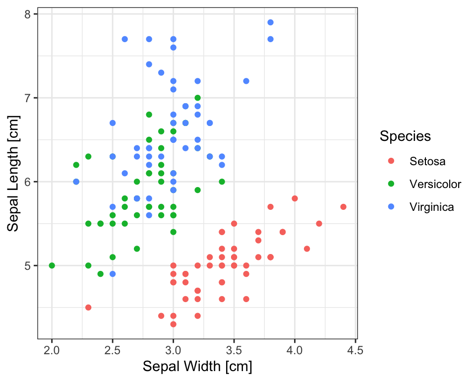

```r
iris %>%
  mutate(Species=str_to_title(Species)) %>%
  ggplot(aes(x=Sepal.Width, y=Sepal.Length, color=Species)) +
  geom_point()  +
  labs(x="Sepal Width [cm]", y="Sepal Length [cm]")
```

The dots appear regularly spaced and could be prone to overplotting. That is, if two observations have the same measurement after rounding, then only the last one plotted would appear in the table. One way to deal with this is to add *jitter* (random uniform noise) to the data.

### Jitter plot

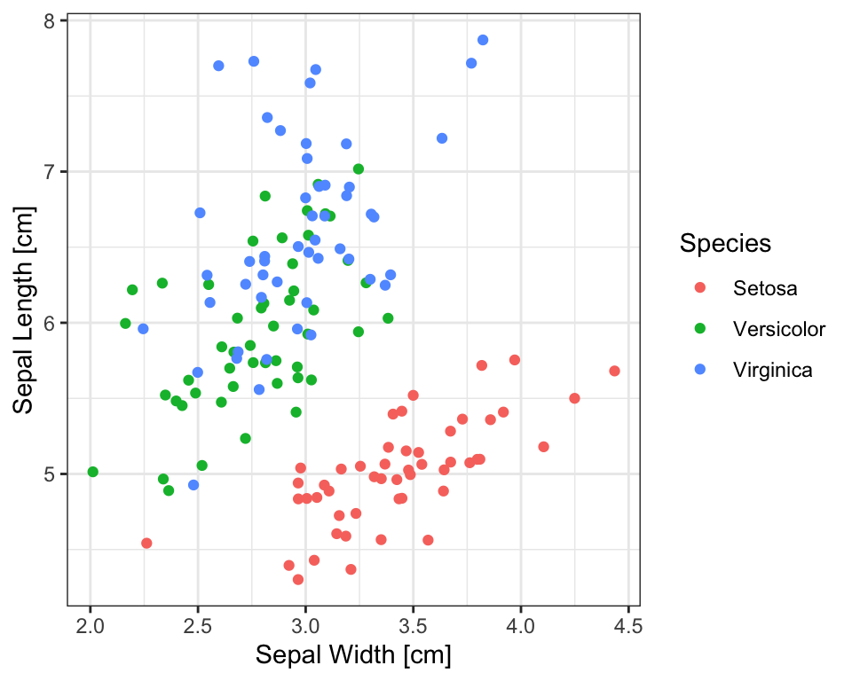

```r
iris %>%
  mutate(Species=str_to_title(Species)) %>%
  ggplot(aes(x=Sepal.Width, y=Sepal.Length, color=Species)) +
  geom_jitter(width=0.05, height=0.05)  +
  labs(x="Sepal Width [cm]", y="Sepal Length [cm]")
```

We use a jitter of 0.05 cm, which should be reasonable given the resolution of the data appeared to be 0.1 cm. It should also be noted that the reproducibility of this particular figure depends on the value given to `set.seed` in the **Parameters** section.

## Comparing Sepal Width across Species

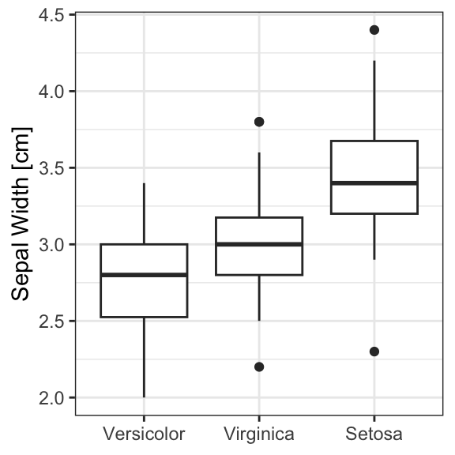

```r
iris %>%
  mutate(Species=reorder(str_to_title(Species), Sepal.Width, FUN=median)) %>%
  ggplot(aes(x=Species, y=Sepal.Width)) +
  geom_boxplot() +
  labs(x=NULL, y="Sepal Width [cm]")
```

We observe the median sepal width is widest in the *I. setosa* species.

# Conclusion

This document demonstrated a few typical practices in an R Markdown document.